# Project: WeRateDogs Wrangling - Data Analysis and Visualization

- INTRODUCTION
- Loading the libraries
- Data gathering
- Reading twitter-archive-enhanced dataset into a dataframe
- Downloading image prediction dataframe using request
- Reading image prediction into a dataframe
- Query tweet_json dataset using twitter API
- Reading tweet_json into a dataframe
- Assessing data
- Objectives
- Methodology
- Visual assessment of twitter_archive_df
- Programmatic assessment of twitter_achive_df
- Visual assessment of image_predictions_df
- Programmatic assessment of image_predictions_df
- Visual assessment of tweet_status
- Programmatic assessment of tweet_status dataframe
- Project scope
- Quality issues
- Tidiness issues
- Cleaning data
- Making the copy of the dataframes
- Quality issue #8: Convert tweet_id column in image_predictions_clean from int to str
- Quality Issue #6: Inconsistent use of lowercase and uppercase and underscores in p1, p2,p3 columns
- Quality Issue #7: Removing duplicated values img_url of image_prediction_df
- Quality Issue #4: Incorrect values and incorrect type for timestamp
- Quality Issue #1: invalid and missing dog name in the column name
- Tidiness Issue #1 : Column source contain HTML tag and hyperlinks
- quality Issue #10: Removing RT @ in column text of twitter_archive_clean
- Quality Issue #5 : dropping columns in_reply_to_status_id, in_reply_to_user_id, retweeted_status_id,retweeted_status_user_id, retweeted_status_timestamp
- Tidiness Issue #2: Merging columns doggo, floofer,pupper, and puppo
- Tidiness Issue #4: There are two information in a single column text url link and text
- Quality Issue #2 and 3#: Invalid ratings. Value varies from 1776 to 0. data type must be converted from int to float. Invalid denominator, I expected a fixed base. data Strucutre must be converted from int to float.
- Tidiness Issue #5: Merging twitter_archive_clean and image_predictions_clean
- Quality Issue #9: Incorrect data type in column id in tweet_status_clean
- Tidiness isssue #6: Creating a dataframe with columns: id, favorite_count, retweet_count
- Tidiness isssue #7: Merge tweet_status_clean and twitter_achive_merged
- Storing the master data into csv file
- ANALYSING AND VISUALIZING THE DATA
- Reading the twitter_archive_master.csv into a dataframe
- Checking for null value
- Dropping the rows containing the null value
- Insight about the clean master dataset
- Visualizing the hidden pattern in the dataset
- Function to plot the average count of tweets
- Visualizing the distribution of average favorite count of tweet using based on the dog category
- Visualizing the distribution of average retweet count based on the dog category
- Visualizing Likes vs Retweets
- Visualizing the most used devices by WeRateDogs users
- Visualizing the most popular name of the dogs
- Visualizing 20 dogs breed P2 predicted by twitter user on WeRateDogs
- Visualizing 20 dogs breed P3 predicted by twitter user on WeRateDogs
- Visualizing the dog category with the highest score
- Visualizing the dog category with maximun favorite count
- Visualizing the dog category with minimun retweet count
- Visualizing Total Tweets made by WeRateDogs per month between 2015 to 2017
- Visualizing some of the dogs image prediction p1

## Introduction

The project 2 **WeRateDogs** a twitter account which has 9.3 million followers across the world at the point this blog is published contains three datatsets namely **twitter-archive-enhanced.csv**, **image_predictions.tsv** and **tweet_json.txt** which we have to programmatically download from three different sources. Two from website URLs and the last one requires the learner to sign up for twitter developer account to collect additional tweet through twitter API. The objective of this project is to challenge the learner to wrangle the three datasets and to combine all the three clean datasets into a twitter master archive by providing at least four insights and two visualizations.

#### Loading the required libraries

```python
from timeit import default_timer as timer
from IPython.display import Image
from tweepy import OAuthHandler
import matplotlib.pyplot as plt
import seaborn as sns
import datetime as dt
import pandas as pd
import numpy as np
%matplotlib inline
import requests
import tweepy
import json
import re
```

## Data Gathering

In this section we are going to download and load the three dataset

### Reading the twitter-archive-enhanced.csv

```python
twitter_archive_df = pd.read_csv('twitter-archive-enhanced.csv')
```

#### Use the Requests library to download the tweet image prediction (image_predictions.tsv)

```python
# Use Requests library to programmatically download tsv file from a website
url = 'https://d17h27t6h515a5.cloudfront.net/topher/2017/August/599fd2ad_image-predictions/image-predictions.tsv'
response = requests.get(url)
# Save tsv to file
with open('image_predictions.tsv', mode='wb') as file:
 file.write(response.content)
```

### Reading image_predictions.tsv in dataframe

```python
image_predictions_df = pd.read_csv('image_predictions.tsv', sep='\t')
```

#### Use the Tweepy library to query additional data via the Twitter API (tweet_json.txt)

One of the Project requirements is to access the Twitter API to create the tweet_json.txt completing some missing/wrong values of the tweet-json file. I will use the tweepy package (a client code) to access the Twitter API.

#### Authentication Details: load personal API keys (replaced with placeholders)

```python
consumer_key = ''
consumer_secret = ''
access_token = ''
access_secret = ''
# variables for Twitter API connection
auth = tweepy.OAuthHandler(consumer_key, consumer_secret)
auth.set_access_token(access_token, access_secret)
api = tweepy.API(auth, wait_on_rate_limit = True)
```

#### Collecting tweet data using API

```python
tweet_ids = twitter_archive_df.tweet_id.values
len(tweet_ids)

# Query Twitter's API for JSON data for each tweet ID in the Twitter archive
count = 0
fails_dict = {}
start = timer()
# Save each tweet's returned JSON as a new line in a .txt file
with open('tweet_json.txt', 'w') as outfile:
    # This loop will likely take 20-30 minutes to run because of Twitter's rate limit
    for tweet_id in tweet_ids:
        count += 1
        print(str(count) + ": " + str(tweet_id))
        try:
            tweet = api.get_status(tweet_id, tweet_mode='extended')
            print("Success")
            json.dump(tweet._json, outfile)
            outfile.write('\n')
        except Exception as e:
            print("Fail")
            fails_dict[tweet_id] = e
            pass
end = timer()
print(end - start)
print(fails_dict)
```

#### Reading tweet JSON content as pandas dataframe

```python
tweet_status_df = pd.read_json('tweet_json.txt', lines = True,encoding='utf-8')
```

## Assessing Data

#### Objectives

In this section, I detect and I document at least eight (8) quality issues and two (2) tidiness issue by using visual assessment and programmatic assessement  
The issues could be defined into two types:

- Quality issues or dirty data: missing, duplicated, or incorrect data
- Tidiness issues: messy data or unstructural data.

#### Methodology

I use visual assessment on each dataframe to detect the issues and document it.

### Visual assessment of twitter_archive_df

```python
twitter_archive_df.sample(3)
```

|  | tweet_id | in_reply_to_status_id | in_reply_to_user_id | timestamp | source | text | retweeted_status_id | retweeted_status_user_id | retweeted_status_timestamp | expanded_urls | rating_numerator | rating_denominator | name | doggo | floofer | pupper | puppo |
| --- | --- | --- | --- | --- | --- | --- | --- | --- | --- | --- | --- | --- | --- | --- | --- | --- | --- |
| 711 | 784517518371221505 | NaN | NaN | 2016-10-07 22:15:26 +0000 | <a href="http://twitter.com/download/iphone" r... | This is Frankie. He has yet to learn how to co... | NaN | NaN | NaN | https://twitter.com/dog_rates/status/784517518... | 11 | 10 | Frankie | None | None | None | None |
| 1273 | 709207347839836162 | NaN | NaN | 2016-03-14 02:39:42 +0000 | <a href="http://twitter.com/download/iphone" r... | This is Penny. She's trying on her prom dress.... | NaN | NaN | NaN | https://twitter.com/dog_rates/status/709207347... | 11 | 10 | Penny | None | None | None | None |
| 470 | 816816676327063552 | NaN | NaN | 2017-01-05 01:20:46 +0000 | <a href="http://twitter.com/download/iphone" r... | This is Timber. He misses Christmas. Specifica... | NaN | NaN | NaN | https://twitter.com/dog_rates/status/816816676... | 12 | 10 | Timber | None | None | None | None |

- We notice quality issue in column name cause it contains invalid name and missing name which are not accurate
- We notice tidiness issue in columns source HTML tags, URL, and content in a single column.

### Programmatic assessment of twitter_archive_df

Through visual assessment we found invalid name in column name of the dataframe.

```python
twitter_archive_df['name'][:20]
```

```
0      Phineas
1        Tilly
2       Archie
3        Darla
4     Franklin
5         None
6          Jax
7         None
8         Zoey
9       Cassie
10        Koda
11       Bruno
12        None
13         Ted
14      Stuart
15      Oliver
16         Jim
17        Zeke
18     Ralphus
19      Canela
Name: name, dtype: object
```

#### Counting the occurence of the unique name of the dogs

```python
twitter_archive_df['name'].value_counts()[:20]
```

```
None       745
a           55
Charlie     12
Cooper      11
Lucy        11
Oliver      11
Tucker      10
Penny       10
Lola        10
Winston      9
Bo           9
Sadie        8
the          8
Daisy        7
Buddy        7
Toby         7
an           7
Bailey       7
Leo          6
Oscar        6
Name: name, dtype: int64
```

#### - We notice 745 dogs in the dataframe have the name None and 55 dogs have the name a

#### - Exploring the rating denominateur

```python
twitter_archive_df['rating_denominator'][:20]
```

```
0     10
1     10
2     10
3     10
4     10
5     10
6     10
7     10
8     10
9     10
10    10
11    10
12    10
13    10
14    10
15    10
16    10
17    10
18    10
19    10
Name: rating_denominator, dtype: int64
```

### Displaying the unique occurance of the denominator rating value

```python
twitter_archive_df['rating_denominator'].value_counts()[:20]
```

```
10     2333
11        3
50        3
20        2
80        2
70        1
7         1
15        1
150       1
170       1
0         1
90        1
40        1
130       1
110       1
16        1
120       1
2         1
Name: rating_denominator, dtype: int64
```

We notice incorrect value in the rating_denominator column cause it must have a same denomination which is 10 leading to accuracy quality issue

### Displaying the rating_numerator column

```python
twitter_archive_df['rating_numerator']
```

```
0       13
1       13
2       12
3       13
4       12
        ..
2351     5
2352     6
2353     9
2354     7
2355     8
Name: rating_numerator, Length: 2356, dtype: int64
```

```python
twitter_archive_df['rating_numerator'].value_counts()[:20]
```

```
12     558
11     464
10     461
13     351
9      158
8      102
7       55
14      54
5       37
6       32
3       19
4       17
2        9
1        9
75       2
15       2
420      2
0        2
80       1
144      1
Name: rating_numerator, dtype: int64
```

The numerator values must be between 0 to 10 which is not the case leading to accuracy quality issue

## Displaying the information about the twitter_archive_df

```python
twitter_archive_df.info()
```

```
<class 'pandas.core.frame.DataFrame'>
RangeIndex: 2356 entries, 0 to 2355
Data columns (total 17 columns):
 #   Column                      Non-Null Count  Dtype
---  ------                      --------------  -----
 0   tweet_id                    2356 non-null   int64
 1   in_reply_to_status_id       78 non-null     float64
 2   in_reply_to_user_id         78 non-null     float64
 3   timestamp                   2356 non-null   object
 4   source                      2356 non-null   object
 5   text                        2356 non-null   object
 6   retweeted_status_id         181 non-null    float64
 7   retweeted_status_user_id    181 non-null    float64
 8   retweeted_status_timestamp  181 non-null    object
 9   expanded_urls               2297 non-null   object
 10  rating_numerator            2356 non-null   int64
 11  rating_denominator          2356 non-null   int64
 12  name                        2356 non-null   object
 13  doggo                       2356 non-null   object
 14  floofer                     2356 non-null   object
 15  pupper                      2356 non-null   object
 16  puppo                       2356 non-null   object
dtypes: float64(4), int64(3), object(10)
memory usage: 313.0+ KB
```

From the programmatic assessment we notice that some quality issues

- timestamp column need to be converted to datetime

```python
twitter_archive_df.pupper
```

```
0       None
1       None
2       None
3       None
4       None
        ...
2351    None
2352    None
2353    None
2354    None
2355    None
Name: pupper, Length: 2356, dtype: object
```

```python
twitter_archive_df.doggo
```

```
0       None
1       None
2       None
3       None
4       None
        ...
2351    None
2352    None
2353    None
2354    None
2355    None
Name: doggo, Length: 2356, dtype: object
```

```python
twitter_archive_df.floofer
```

```
0       None
1       None
2       None
3       None
4       None
        ...
2351    None
2352    None
2353    None
2354    None
2355    None
Name: floofer, Length: 2356, dtype: object
```

```python
twitter_archive_df.puppo
```

```
0       None
1       None
2       None
3       None
4       None
        ...
2351    None
2352    None
2353    None
2354    None
2355    None
Name: puppo, Length: 2356, dtype: object
```

- From programmatic assessment we find a tidiness issue on columns doggo, floofer,pupper, and puppo they all have the same name and can be merge into 1 column

### Checking for null values

```python
twitter_archive_df.isnull().sum()
```

```
tweet_id                         0
in_reply_to_status_id         2278
in_reply_to_user_id           2278
timestamp                        0
source                           0
text                             0
retweeted_status_id           2175
retweeted_status_user_id      2175
retweeted_status_timestamp    2175
expanded_urls                   59
rating_numerator                 0
rating_denominator               0
name                             0
doggo                            0
floofer                          0
pupper                           0
puppo                            0
dtype: int64
```

in_reply_to_status_id, in_reply_to_user_id ,retweeted_status_id,retweeted_status_user_id, retweeted_status_timestamp columns have more null values which will bring bring about a quality issue we need to drop them

```python
twitter_archive_df.text[:20]
```

```
0     This is Phineas. He's a mystical boy. Only eve...
1     This is Tilly. She's just checking pup on you....
2     This is Archie. He is a rare Norwegian Pouncin...
3     This is Darla. She commenced a snooze mid meal...
4     This is Franklin. He would like you to stop ca...
5     Here we have a majestic great white breaching ...
6     Meet Jax. He enjoys ice cream so much he gets ...
7     When you watch your owner call another dog a g...
8     This is Zoey. She doesn't want to be one of th...
9     This is Cassie. She is a college pup. Studying...
10    This is Koda. He is a South Australian decksha...
11    This is Bruno. He is a service shark. Only get...
12    Here's a puppo that seems to be on the fence a...
13    This is Ted. He does his best. Sometimes that'...
14    This is Stuart. He's sporting his favorite fan...
15    This is Oliver. You're witnessing one of his m...
16    This is Jim. He found a fren. Taught him how t...
17    This is Zeke. He has a new stick. Very proud o...
18    This is Ralphus. He's powering up. Attempting ...
19    RT @dog_rates: This is Canela. She attempted s...
Name: text, dtype: object
```

### Checking the occurence of RT in the text column as it must be removed as specified in the project requirement

```python
display(twitter_archive_df[twitter_archive_df['text'].str.contains('RT @')])
print('the number of RT in the text is:', sum(twitter_archive_df['text'].str.contains('RT @')))
```

|  | tweet_id | in_reply_to_status_id | in_reply_to_user_id | timestamp | source | text | retweeted_status_id | retweeted_status_user_id | retweeted_status_timestamp | expanded_urls | rating_numerator | rating_denominator | name | doggo | floofer | pupper | puppo |
| --- | --- | --- | --- | --- | --- | --- | --- | --- | --- | --- | --- | --- | --- | --- | --- | --- | --- |
| 19 | 888202515573088257 | NaN | NaN | 2017-07-21 01:02:36 +0000 | <a href="http://twitter.com/download/iphone" r... | RT @dog_rates: This is Canela. She attempted s... | 8.874740e+17 | 4.196984e+09 | 2017-07-19 00:47:34 +0000 | https://twitter.com/dog_rates/status/887473957... | 13 | 10 | Canela | None | None | None | None |
| 32 | 886054160059072513 | NaN | NaN | 2017-07-15 02:45:48 +0000 | <a href="http://twitter.com/download/iphone" r... | RT @Athletics: 12/10 #BATP https://t.co/WxwJmv... | 8.860537e+17 | 1.960740e+07 | 2017-07-15 02:44:07 +0000 | https://twitter.com/dog_rates/status/886053434... | 12 | 10 | None | None | None | None | None |
| 36 | 885311592912609280 | NaN | NaN | 2017-07-13 01:35:06 +0000 | <a href="http://twitter.com/download/iphone" r... | RT @dog_rates: This is Lilly. She just paralle... | 8.305833e+17 | 4.196984e+09 | 2017-02-12 01:04:29 +0000 | https://twitter.com/dog_rates/status/830583320... | 13 | 10 | Lilly | None | None | None | None |
| 68 | 879130579576475649 | NaN | NaN | 2017-06-26 00:13:58 +0000 | <a href="http://twitter.com/download/iphone" r... | RT @dog_rates: This is Emmy. She was adopted t... | 8.780576e+17 | 4.196984e+09 | 2017-06-23 01:10:23 +0000 | https://twitter.com/dog_rates/status/878057613... | 14 | 10 | Emmy | None | None | None | None |
| 73 | 878404777348136964 | NaN | NaN | 2017-06-24 00:09:53 +0000 | <a href="http://twitter.com/download/iphone" r... | RT @dog_rates: Meet Shadow. In an attempt to r... | 8.782815e+17 | 4.196984e+09 | 2017-06-23 16:00:04 +0000 | https://www.gofundme.com/3yd6y1c,https://twitt... | 13 | 10 | Shadow | None | None | None | None |
| ... | ... | ... | ... | ... | ... | ... | ... | ... | ... | ... | ... | ... | ... | ... | ... | ... | ... |
| 1023 | 746521445350707200 | NaN | NaN | 2016-06-25 01:52:36 +0000 | <a href="http://twitter.com/download/iphone" r... | RT @dog_rates: This is Shaggy. He knows exactl... | 6.678667e+17 | 4.196984e+09 | 2015-11-21 00:46:50 +0000 | https://twitter.com/dog_rates/status/667866724... | 10 | 10 | Shaggy | None | None | None | None |
| 1043 | 743835915802583040 | NaN | NaN | 2016-06-17 16:01:16 +0000 | <a href="http://twitter.com/download/iphone" r... | RT @dog_rates: Extremely intelligent dog here.... | 6.671383e+17 | 4.196984e+09 | 2015-11-19 00:32:12 +0000 | https://twitter.com/dog_rates/status/667138269... | 10 | 10 | None | None | None | None | None |
| 1242 | 711998809858043904 | NaN | NaN | 2016-03-21 19:31:59 +0000 | <a href="http://twitter.com/download/iphone" r... | RT @twitter: @dog_rates Awesome Tweet! 12/10. ... | 7.119983e+17 | 7.832140e+05 | 2016-03-21 19:29:52 +0000 | https://twitter.com/twitter/status/71199827977... | 12 | 10 | None | None | None | None | None |
| 2259 | 667550904950915073 | NaN | NaN | 2015-11-20 03:51:52 +0000 | <a href="http://twitter.com" rel="nofollow">Tw... | RT @dogratingrating: Exceptional talent. Origi... | 6.675487e+17 | 4.296832e+09 | 2015-11-20 03:43:06 +0000 | https://twitter.com/dogratingrating/status/667... | 12 | 10 | None | None | None | None | None |
| 2260 | 667550882905632768 | NaN | NaN | 2015-11-20 03:51:47 +0000 | <a href="http://twitter.com" rel="nofollow">Tw... | RT @dogratingrating: Unoriginal idea. Blatant ... | 6.675484e+17 | 4.296832e+09 | 2015-11-20 03:41:59 +0000 | https://twitter.com/dogratingrating/status/667... | 5 | 10 | None | None | None | None | None |

181 rows × 17 columns

```
the number of RT in the text is: 181
```

- Programmatically this is a quality issue cause text columns contains text and Url andv 181 retweets

### Visual assessment of image_predictions_df

```python
image_predictions_df.sample(4)
```

|  | tweet_id | jpg_url | img_num | p1 | p1_conf | p1_dog | p2 | p2_conf | p2_dog | p3 | p3_conf | p3_dog |
| --- | --- | --- | --- | --- | --- | --- | --- | --- | --- | --- | --- | --- |
| 915 | 701214700881756160 | https://pbs.twimg.com/media/Cbs3DOAXIAAp3Bd.jpg | 1 | Chihuahua | 0.615163 | True | Pembroke | 0.159509 | True | basenji | 0.084466 | True |
| 476 | 675153376133427200 | https://pbs.twimg.com/media/CV6gaUUWEAAnETq.jpg | 1 | paper_towel | 0.327957 | False | mailbox | 0.096027 | False | seat_belt | 0.034995 | False |
| 592 | 679462823135686656 | https://pbs.twimg.com/media/CW3v1KxW8AAIOuy.jpg | 1 | toy_poodle | 0.621780 | True | miniature_poodle | 0.197819 | True | soft-coated_wheaten_terrier | 0.046745 | True |
| 1036 | 711968124745228288 | https://pbs.twimg.com/media/CeFrO3qXEAADRbd.jpg | 1 | espresso | 0.430135 | False | coffee_mug | 0.418483 | False | cup | 0.088391 | False |

From visual assessment we notice a quality issue on colums p1, p2 and p3 inconsistancy in the spelling of the name using upper case letter, lower case and underscore

```python
### Visualizing
```

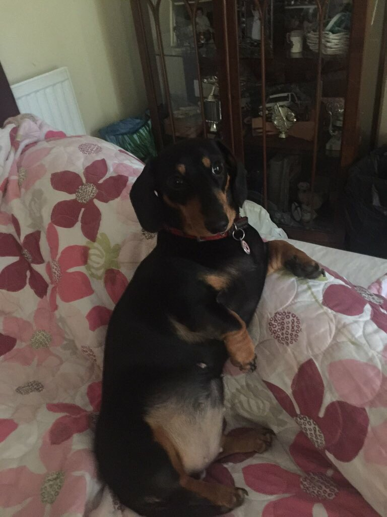

```python
Image("https://pbs.twimg.com/media/CT5IQmsXIAAKY4A.jpg") miniature_pinscher
```

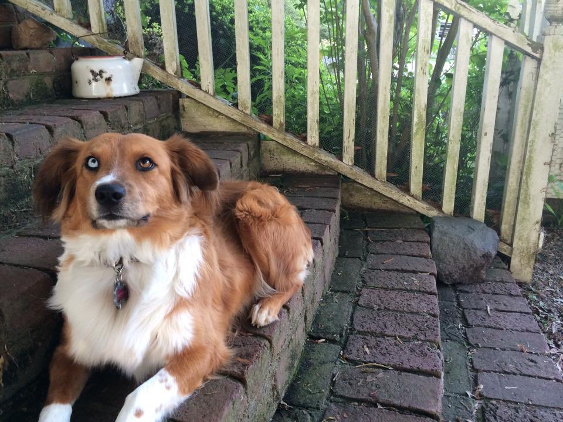

```python
Image("https://pbs.twimg.com/media/CT4udn0WwAA0aMy.jpg")
```

[figure not shown]

```python
Image("https://pbs.twimg.com/media/DGGmoV4XsAAUL6n.jpg")
```

### Programmatic assessment of image_prediction dataframe

#### Displaying the description of the image_predictions.tsv

```python
image_predictions_df.info()
```

```
<class 'pandas.core.frame.DataFrame'>
RangeIndex: 2075 entries, 0 to 2074
Data columns (total 12 columns):
 #   Column    Non-Null Count  Dtype
---  ------    --------------  -----
 0   tweet_id  2075 non-null   int64
 1   jpg_url   2075 non-null   object
 2   img_num   2075 non-null   int64
 3   p1        2075 non-null   object
 4   p1_conf   2075 non-null   float64
 5   p1_dog    2075 non-null   bool
 6   p2        2075 non-null   object
 7   p2_conf   2075 non-null   float64
 8   p2_dog    2075 non-null   bool
 9   p3        2075 non-null   object
 10  p3_conf   2075 non-null   float64
 11  p3_dog    2075 non-null   bool
dtypes: bool(3), float64(3), int64(2), object(4)
memory usage: 152.1+ KB
```

- From the descriptive information of the image_predictions dataframe, tweet_id need to be converted to a String data type cause it does not affect our analysis . So we raise a quality issue on the validity of the tweet_id data type

### Checking for duplicated value

```python
sum(image_predictions_df['tweet_id'].duplicated())
```

```
0
```

```python
sum(image_predictions_df.jpg_url.duplicated())
```

```
66
```

They are 66 duplicated jpg_url double entry bringing about a quality issue on the validity of the data

### Visual assessment of tweet_status

```python
tweet_status_df.sample(4)
```

|  | created_at | id | id_str | full_text | truncated | display_text_range | entities | extended_entities | source | in_reply_to_status_id | ... | favorited | retweeted | possibly_sensitive | possibly_sensitive_appealable | lang | retweeted_status | quoted_status_id | quoted_status_id_str | quoted_status_permalink | quoted_status |
| --- | --- | --- | --- | --- | --- | --- | --- | --- | --- | --- | --- | --- | --- | --- | --- | --- | --- | --- | --- | --- | --- |
| 113 | 2017-05-31 04:27:59+00:00 | 869772420881756160 | 869772420881756160 | This is Dewey (pronounced "covfefe"). He's hav... | False | [0, 110] | {'hashtags': [], 'symbols': [], 'user_mentions... | {'media': [{'id': 869772408907071492, 'id_str'... | <a href="http://twitter.com/download/iphone" r... | NaN | ... | False | False | 0.0 | 0.0 | en | NaN | NaN | NaN | NaN | NaN |
| 1065 | 2016-05-29 01:49:16+00:00 | 736736130620620800 | 736736130620620800 | This is Chadrick. He's gnarly af 13/10 https:/... | False | [0, 38] | {'hashtags': [], 'symbols': [], 'user_mentions... | {'media': [{'id': 736736122429014017, 'id_str'... | <a href="http://twitter.com/download/iphone" r... | NaN | ... | False | False | 0.0 | 0.0 | en | NaN | NaN | NaN | NaN | NaN |
| 321 | 2017-02-16 23:23:38+00:00 | 832369877331693569 | 832369877331693568 | This is Charlie. He fell asleep on a heating v... | False | [0, 112] | {'hashtags': [], 'symbols': [], 'user_mentions... | {'media': [{'id': 832369869089800192, 'id_str'... | <a href="http://twitter.com/download/iphone" r... | NaN | ... | False | False | 0.0 | 0.0 | en | NaN | NaN | NaN | NaN | NaN |
| 1946 | 2015-12-05 04:25:50+00:00 | 672995267319328768 | 672995267319328768 | This is Pumpkin. He can look in two different ... | False | [0, 120] | {'hashtags': [], 'symbols': [], 'user_mentions... | {'media': [{'id': 672995232229781504, 'id_str'... | <a href="http://twitter.com/download/iphone" r... | NaN | ... | False | False | 0.0 | 0.0 | en | NaN | NaN | NaN | NaN | NaN |

4 rows × 32 columns

- We notice tidy issue in column in_reply_to_status_id, retweeted_status, quoted_status_id, quoted_status_id_str, quoted_status having NaN value
- We notice tidiness issue in columns source, entities, extended_entities having HTML tags, URL
- full_text contains RT @ which need to be remove per the project requirement

### Programmatic assessment of tweet_status_df

```python
tweet_status_df.isnull().sum()
```

```
created_at                          0
id                                  0
id_str                              0
full_text                           0
truncated                           0
display_text_range                  0
entities                            0
extended_entities                 270
source                              0
in_reply_to_status_id            2249
in_reply_to_status_id_str        2249
in_reply_to_user_id              2249
in_reply_to_user_id_str          2249
in_reply_to_screen_name          2249
user                                0
geo                              2326
coordinates                      2326
place                            2325
contributors                     2326
is_quote_status                     0
retweet_count                       0
favorite_count                      0
favorited                           0
retweeted                           0
possibly_sensitive                132
possibly_sensitive_appealable     132
lang                                0
retweeted_status                 2166
quoted_status_id                 2300
quoted_status_id_str             2300
quoted_status_permalink          2300
quoted_status                    2302
dtype: int64
```

- we have quality issue on the validity of the data entry of the columns listed below having high number of NaN values therefore we need to drop  
  in_reply_to_status_id  
  in_reply_to_status_id_str  
  in_reply_to_user_id  
  in_reply_to_user_id_str  
  in_reply_to_screen_name  
  geo  
  coordinates  
  place  
  contributors  
  retweeted_status  
  quoted_status_id  
  quoted_status_id_str  
  quoted_status

```python
tweet_status_df.info()
```

```
<class 'pandas.core.frame.DataFrame'>
RangeIndex: 2326 entries, 0 to 2325
Data columns (total 32 columns):
 #   Column                         Non-Null Count  Dtype
---  ------                         --------------  -----
 0   created_at                     2326 non-null   datetime64[ns, UTC]
 1   id                             2326 non-null   int64
 2   id_str                         2326 non-null   int64
 3   full_text                      2326 non-null   object
 4   truncated                      2326 non-null   bool
 5   display_text_range             2326 non-null   object
 6   entities                       2326 non-null   object
 7   extended_entities              2056 non-null   object
 8   source                         2326 non-null   object
 9   in_reply_to_status_id          77 non-null     float64
```

[output cut: 24 more lines]

### Project scope

Based on the tidiness concept, twitter_archive_enhanced.csv,tweet_status_df, image_predictions.tsv should be merged using the tweet_id as a mapping key

### Quality issues

1. invalid and missing dog name in the column name of twitter_achive_df
2. Invalid ratings in column rating_numerator of twitter_achive_df value varies from 1776 to 0 and data type need to be converted from int to float
3. Invalid denominator in column rating_denominator of twitter_achive_df. It should be a fixed base 10 and data type need to be converted from int to float.
4. Timestamp column in twitter_achive_df needs to be converted into datetime data type
5. in_reply_to_status_id, in_reply_to_user_id ,retweeted_status_id,retweeted_status_user_id, retweeted_status_timestamp have missing data
6. Spelling inconsistency of upper case letter in columns p1, p2 and p3 of image_predictions_df
7. jpg_url columns in image_predictions_df has 66 duplicated images and for the accurary of the data we need to drop them
8. tweet_id in image_predictions_df needs to be converted to string
9. column id in tweet_status_df need to be converted from in to string
10. column id need to be converted in tweet_id

### Tidiness issues

1. HTML tags, URL, and content in source column
2. columns doggo, floofer,pupper, and puppo they all have the same name and can be merge into 1 column
3. twitter_archive_df and image_predictions_df and tweet_status_df can be marged
4. There is two information in a single column text, ampasand and //n
5. 3 useful columns: id, favorite_count, retweet_count in tweet_status_df
6. Retweet need to be removed in text column and in full_text columns

## Cleaning Data

In this section, we clean all of the issues I listed out above while assessing the data.

### Making copies of the original dataframes

```python
twitter_archive_clean = twitter_archive_df.copy()
image_predictions_clean = image_predictions_df.copy()
tweet_status_clean = tweet_status_df.copy()
```

### Quality Issue #8:

Convert tweet_id column in image_predictions_clean from int to str

#### Define: Converting tweet_id column from int to str

#### Code

```python
image_predictions_clean.tweet_id = image_predictions_clean.tweet_id.astype(str)
```

#### Test

```python
type(image_predictions_clean.tweet_id[0])
```

```
str
```

### Quality Issue #6:

Inconsistent use of lowercase and uppercase and underscores in p1, p2,p3 columns

#### Define: Replacing underscores ('_') with spaces and capitalize first letter.

#### Code

```python
image_predictions_clean.p1 = image_predictions_clean.p1.str.replace('_', " ").str.capitalize()
image_predictions_clean.p2 = image_predictions_clean.p2.str.replace('_', " ").str.capitalize()
image_predictions_clean.p3 = image_predictions_clean.p3.str.replace('_', " ").str.capitalize()
```

#### Test

```python
image_predictions_clean[['p1','p2','p3']].sample(6)
```

|  | p1 | p2 | p3 |
| --- | --- | --- | --- |
| 2065 | Pembroke | Cardigan | Chihuahua |
| 657 | Seat belt | Lakeland terrier | Airedale |
| 299 | German shepherd | Kelpie | Red wolf |
| 1424 | Golden retriever | Irish setter | Vizsla |
| 821 | Ice lolly | Neck brace | Yorkshire terrier |
| 1533 | Tub | Bathtub | Golden retriever |

### Quality Issue #7

Removing duplicated values img_url of image_prediction_df

#### Define:

Indexing all the duplicated value in jpg_url columns ;selecting the the non duplicating values and assigning the non duplicated jpg_url to image_predictions_clean

#### Code

```python
indexing = image_predictions_df.jpg_url.duplicated()
indexing = np.logical_not(indexing)
image_predictions_clean= image_predictions_clean[indexing]
```

#### Test

```python
print("Before cleaning: {} rows.\nAfter cleaning: {} rows.".format(image_predictions_df.shape[0],image_predictions_clean.shape[0]))
```

```
Before cleaning: 2075 rows.
After cleaning: 2009 rows.
```

```python
print("{} duplicated.".format(sum(image_predictions_clean.jpg_url.duplicated())))
```

```
0 duplicated.
```

### Quality Issue #4:

Incorrect values and incorrect type for timestamp

### Define: Converting timestamp column from object to datetime series

### Code

```python
twitter_archive_clean['timestamp'] = twitter_archive_clean['timestamp'].astype('datetime64[ns]')
```

### Test

```python
twitter_archive_clean.timestamp[0]
```

```
Timestamp('2017-08-01 16:23:56')
```

### Quality Issue #1

invalid and missing dog name in the column name

#### Define: Rename non-standard names to "None"

Code

```python
invalid_names=list(twitter_archive_clean[twitter_archive_clean.name.
                                           str.contains('^[a-z].*')].
                   name.value_counts().index) + ['None']
twitter_archive_clean.loc[twitter_archive_clean.name.apply(lambda x: x in invalid_names),'name']=None
```

#### Test

```python
(twitter_archive_clean.name=='None').sum()
```

```
0
```

```python
(twitter_archive_clean.name=='a').sum()
```

```
0
```

```python
(twitter_archive_clean.name.apply(lambda x: x in invalid_names)).sum()
```

```
0
```

twitter_data_archived contains retweets RT @ in column text

#### Define

As per project specification, we only want original dog ratings. We need to remove retweets text column starting with RT @. In order to fix this quality issue, we are going to create vectors to index all the non-retweet and we exclude the subset from the retweeted_status_id, retweeted_status_user_id, and retweeted_status_timestamp In the end we need to reset the index.

#### Code

```python
indexing_retweeted_status_id =twitter_archive_clean.retweeted_status_id.isnull()
twitter_archive_clean = twitter_archive_clean[indexing_retweeted_status_id]
indexing_retweeted_status_user_id = twitter_archive_clean.retweeted_status_user_id.isnull()
twitter_archive_clean = twitter_archive_clean[indexing_retweeted_status_user_id]
indexing_retweeted_status_timestamp = twitter_archive_clean.retweeted_status_timestamp.isnull()
twitter_archive_clean = twitter_archive_clean[indexing_retweeted_status_timestamp ]
```

Test

```python
print("Number of rows with true in retweeted_status_id:", sum(twitter_archive_clean.retweeted_status_id.isnull()))
print("Number of rows with true in retweeted_status_timestamp:", sum(twitter_archive_clean.retweeted_status_timestamp.isnull()))
print("Number of rows with true in retweeted_status_user_id:", sum(twitter_archive_clean.retweeted_status_user_id.isnull()))
print("Number of rows of twitter_archive_clean:",twitter_archive_clean.shape[0])
```

```
Number of rows with true in retweeted_status_id: 2175
Number of rows with true in retweeted_status_timestamp: 2175
Number of rows with true in retweeted_status_user_id: 2175
Number of rows of twitter_archive_clean: 2175
```

```python
display(twitter_archive_clean[twitter_archive_df['text'].str.contains('RT @')])
print('the number of RT in the text is:', sum(twitter_archive_clean['text'].str.contains('RT @')))
```

|  | tweet_id | in_reply_to_status_id | in_reply_to_user_id | timestamp | source | text | retweeted_status_id | retweeted_status_user_id | retweeted_status_timestamp | expanded_urls | rating_numerator | rating_denominator | name | doggo | floofer | pupper | puppo |
| --- | --- | --- | --- | --- | --- | --- | --- | --- | --- | --- | --- | --- | --- | --- | --- | --- | --- |

```
the number of RT in the text is: 0
```

```python
twitter_archive_clean['text'].sample(45)
```

```
1670    This is Patrick. He's a bigass pupper. 7/10 ht...
960     "This photographer took pics of her best frien...
1982    This is Gustaf. He's a purebred Chevy Equinox....
1589    This is Mona. She's a Yarborough Splishnsplash...
2138    😂😂😂 10/10 for the dog and the owner https://t....
1120    Say hello to this unbelievably well behaved sq...
1358    This is Charlie. He's a West Side Niddlewog. M...
320     Meet Chester (bottom) &amp; Harold (top). They...
1288    This is River. He's changing the trumpet game....
1600    This pupper has a magical eye. 11/10 I can't s...
226     Please stop sending in animals other than dogs...
660     This is Mabel. She's super h*ckin smol. Portab...
1923    This is a Sagitariot Baklava mix. Loves her ne...
1326    This is Layla. She's giving you a standing ova...
551     HE'S TRYING TO BE HIS OWN PERSON LET HIM GO 13...
```

[output cut: 31 more lines]

### Tidiness Issue #1

Column source contain HTML tag and hyperlinks

#### Define: Extracting the content between opening and closing tag using regular expressions.

Extracting the link.  
Replacing source variable in the dataset with just the source name  
Creating additional table with source link that we could use as a lookup table.

#### Code

```python
source_link = twitter_archive_clean.source.str.extract(r'<a href="(.+)" .+>', expand=False)
source = twitter_archive_clean.source.str.extract(r'>([A-z -]+)<', expand=False)
twitter_archive_clean.source = source
```

```python
sources = pd.DataFrame({'source': source, 'source_link': source_link})
sources.drop_duplicates(inplace=True)
```

```python
sources
```

|  | source | source_link |
| --- | --- | --- |
| 0 | Twitter for iPhone | http://twitter.com/download/iphone |
| 209 | Twitter Web Client | http://twitter.com |
| 529 | Vine - Make a Scene | http://vine.co |
| 972 | TweetDeck | https://about.twitter.com/products/tweetdeck |

#### Test

```python
twitter_archive_clean.source.value_counts()
```

```
Twitter for iPhone     2042
Vine - Make a Scene      91
Twitter Web Client       31
TweetDeck                11
Name: source, dtype: int64
```

#### Quality issue

Dropping columns in_reply_to_status_id, in_reply_to_user_id, retweeted_status_id,retweeted_status_user_id, retweeted_status_timestamp and expanded_urls

### Define:

Removing the columns in_reply_to_status_id, in_reply_to_user_id ,retweeted_status_id,retweeted_status_user_id, retweeted_status_timestamp

### Code

```python
columns_to_remove = ['in_reply_to_user_id', 'in_reply_to_status_id',
                    'retweeted_status_id', 'retweeted_status_user_id',
                    'retweeted_status_timestamp','expanded_urls']
twitter_archive_clean.drop(columns_to_remove, axis=1, inplace=True)
```

### Test

```python
twitter_archive_clean.columns
```

```
Index(['tweet_id', 'timestamp', 'source', 'text', 'rating_numerator',
       'rating_denominator', 'name', 'doggo', 'floofer', 'pupper', 'puppo'],
      dtype='object')
```

### Tidiness Issue #2

Merging columns doggo, floofer,pupper, and puppo

### Define

Columns doggo, floofer,pupper, and puppo have the same values therefore can be merged into one feature

### Code

```python
dog_cols = twitter_archive_clean[['doggo','floofer','pupper','puppo']]
dog_cols = dog_cols.replace('None', '')
dog_category = np.array(dog_cols['doggo']) + np.array(dog_cols['floofer']) + np.array(dog_cols['pupper']) + np.array(dog_cols['puppo'])
pd.DataFrame(dog_category, columns = ['dog_category']).dog_category.value_counts()
```

```
                1831
pupper           224
doggo             75
puppo             24
doggopupper       10
floofer            9
doggopuppo         1
doggofloofer       1
Name: dog_category, dtype: int64
```

- Let's convert all double classified dog as multiclass.

```python
dog_category[dog_category == 'doggopupper'] = 'multiclass'
dog_category[dog_category == 'doggofloofer'] = 'multiclass'
dog_category[dog_category == 'doggopuppo'] = 'multiclass'
pd.DataFrame(dog_category, columns = ['dog_category']).dog_category.value_counts()
```

```
              1831
pupper         224
doggo           75
puppo           24
multiclass      12
floofer          9
Name: dog_category, dtype: int64
```

- Appending this new column called dog_category to the twtitter_archive_clean

```python
twitter_archive_clean.reset_index(drop=True, inplace=True)
twitter_archive_clean = pd.concat([twitter_archive_clean, pd.DataFrame(dog_category, columns = ['dog_category'])], axis = 1)
```

- Dropping the individual columns after merging them

```python
columns_to_remove = ['doggo','floofer','pupper','puppo']
twitter_archive_clean.drop(columns_to_remove, axis=1, inplace=True)
```

### Test

```python
twitter_archive_clean.dog_category.value_counts()
```

```
              1831
pupper         224
doggo           75
puppo           24
multiclass      12
floofer          9
Name: dog_category, dtype: int64
```

```python
twitter_archive_clean.columns
```

```
Index(['tweet_id', 'timestamp', 'source', 'text', 'rating_numerator',
       'rating_denominator', 'name', 'dog_category'],
      dtype='object')
```

### Tidiness Issue #4

There are two information in a single column text.

### Code

```python
twitter_archive_clean['text'] = twitter_archive_clean.text.str.replace(r'[(https://.+),(\&amp;)|(\n)]','',regex=True)
```

### Test

```python
twitter_archive_clean['text'].sample(45)
```

[output not shown]

[output cut: 31 more lines]

### Quality Issue #2 and 3 :

Invalid ratings. Value varies from 1776 to 0. data type must be converted from int to float. Invalid denominator, I expected a fixed base. data Strucutre must be converted from int to float.

### Define

- Convert rating_numerator and rating_denominator to float because @dog_rates uses float rating number.
- Remove the extreme values (1776, 420, etc.) of rating_numerator, and;
- Remove non expected value of denominator, anything different of 10.

### Code

- Converting the rating_numerator and rating_denominator to float.

```python
twitter_archive_clean.rating_numerator = twitter_archive_clean.rating_numerator.astype(float)
twitter_archive_clean.rating_denominator = twitter_archive_clean.rating_denominator.astype(float)
```

From visual assessment of the rating_numerator done earlier on, we need to drop the numerator with invalid rating 1776, 420, 204.

```python
invalid_ratings_1776_420_204= twitter_archive_clean[(twitter_archive_clean.rating_numerator==1776)|(twitter_archive_clean.rating_numerator==204)|(twitter_archive_clean.rating_numerator==420)].index
twitter_archive_clean.drop(invalid_ratings_1776_420_204, inplace=True)
```

- Removing tweet_id with 0/10

Listing the tweet_id having 0 as numerator and removing these tweet_id from the dataframe

```python
list(twitter_archive_clean.query('rating_numerator == 0').tweet_id)
```

```
[835152434251116546, 746906459439529985]
```

```python
rm_list = list(twitter_archive_clean.query('rating_numerator == 0').tweet_id)
# Creating a vector to subset twitter_archive_clean and remove the tweet_id from the rm_list.
indexing = np.logical_not(twitter_archive_clean.tweet_id.isin(rm_list))
# Updating the twitter_archive_clean data frame.
twitter_archive_clean = twitter_archive_clean[indexing]
```

### Test

```python
twitter_archive_clean.query('rating_numerator == 0')
```

|  | tweet_id | timestamp | source | text | rating_numerator | rating_denominator | name | dog_category |
| --- | --- | --- | --- | --- | --- | --- | --- | --- |

- Quering denominator other than 10

```python
list(twitter_archive_clean.query('rating_denominator !=10').tweet_id)
```

```
[835246439529840640,
 832088576586297345,
 820690176645140481,
 810984652412424192,
 758467244762497024,
 740373189193256964,
 722974582966214656,
 716439118184652801,
 713900603437621249,
 710658690886586372,
 709198395643068416,
 704054845121142784,
 697463031882764288,
 686035780142297088,
 684225744407494656,
 684222868335505415,
 682962037429899265,
 682808988178739200,
 677716515794329600,
 675853064436391936,
 666287406224695296]
```

```python
rm_list = list(twitter_archive_clean.query('rating_denominator !=10').tweet_id)
# Creating a vector to subset twitter_archive_clean and remove the tweet_id from the rm_list.
indexing = np.logical_not(twitter_archive_clean.tweet_id.isin(rm_list))
# Updating the twitter_archive_clean data frame.
twitter_archive_clean = twitter_archive_clean[indexing]
```

### Test

```python
twitter_archive_clean.query('rating_denominator < 10')
```

|  | tweet_id | timestamp | source | text | rating_numerator | rating_denominator | name | dog_category |
| --- | --- | --- | --- | --- | --- | --- | --- | --- |

```python
twitter_archive_clean.query('rating_denominator > 10')
```

|  | tweet_id | timestamp | source | text | rating_numerator | rating_denominator | name | dog_category |
| --- | --- | --- | --- | --- | --- | --- | --- | --- |

```python
twitter_archive_clean.rating_denominator.value_counts()
```

```
10.0    2148
Name: rating_denominator, dtype: int64
```

```python
twitter_archive_clean.tweet_id =twitter_archive_clean.tweet_id.astype(str)
```

### Merging twitter_archive_clean and image_predictions_clean as stating in the tidiness issue

```python
twitter_archive_merged= pd.DataFrame()
twitter_archive_merged = twitter_archive_clean.copy()
twitter_archive_merged_df  = twitter_archive_merged.merge(image_predictions_clean, on='tweet_id', how='inner')
```

```python
print("Shape df_twitter_archive_clean: " + str(twitter_archive_merged.shape))
print("Shape image_predictions_clean: " + str(image_predictions_clean.shape))
print("Shape df_twitter_combined " + str(twitter_archive_merged_df.shape) + " after joining df_twitter_archive_cleaned, df_tweet_performance and df_image_predictions_cleaned.")
```

[output not shown]

### Test

```python
twitter_archive_merged_df.info()
```

```
<class 'pandas.core.frame.DataFrame'>
Int64Index: 1972 entries, 0 to 1971
Data columns (total 19 columns):
 #   Column              Non-Null Count  Dtype
---  ------              --------------  -----
 0   tweet_id            1972 non-null   object
 1   timestamp           1972 non-null   datetime64[ns]
 2   source              1972 non-null   object
 3   text                1972 non-null   object
 4   rating_numerator    1972 non-null   float64
 5   rating_denominator  1972 non-null   float64
 6   name                1346 non-null   object
 7   dog_category        1972 non-null   object
 8   jpg_url             1972 non-null   object
 9   img_num             1972 non-null   int64
 10  p1                  1972 non-null   object
 11  p1_conf             1972 non-null   float64
 12  p1_dog              1972 non-null   bool
 13  p2                  1972 non-null   object
 14  p2_conf             1972 non-null   float64
 15  p2_dog              1972 non-null   bool
 16  p3                  1972 non-null   object
 17  p3_conf             1972 non-null   float64
 18  p3_dog              1972 non-null   bool
dtypes: bool(3), datetime64[ns](1), float64(5), int64(1), object(9)
memory usage: 267.7+ KB
```

Incorrect data type in column id in tweet_status_clean

#### Define:

Convert id from int to str

#### Code

```python
tweet_status_clean.id = tweet_status_clean.id.astype('str')
tweet_status_clean.rename(columns={'id':'tweet_id'}, inplace=True)
```

### Test

```python
type(tweet_status_clean.tweet_id[0])
```

```
str
```

### Tidiness Issue #11:

Removing RT @ in full_text column

#### Define

Removing RT @ in full_text column as required in the project requirement

#### Code

```python
display(tweet_status_clean[tweet_status_clean['full_text'].str.contains('RT @')])
print('the number of RT in the text is:', sum(tweet_status_clean['full_text'].str.contains('RT @')))
```

|  | created_at | tweet_id | id_str | full_text | truncated | display_text_range | entities | extended_entities | source | in_reply_to_status_id | ... | favorited | retweeted | possibly_sensitive | possibly_sensitive_appealable | lang | retweeted_status | quoted_status_id | quoted_status_id_str | quoted_status_permalink | quoted_status |
| --- | --- | --- | --- | --- | --- | --- | --- | --- | --- | --- | --- | --- | --- | --- | --- | --- | --- | --- | --- | --- | --- |
| 31 | 2017-07-15 02:45:48+00:00 | 886054160059072513 | 886054160059072512 | RT @Athletics: 12/10 #BATP https://t.co/WxwJmv... | False | [0, 50] | {'hashtags': [{'text': 'BATP', 'indices': [21,... | NaN | <a href="http://twitter.com/download/iphone" r... | NaN | ... | False | False | 0.0 | 0.0 | und | {'created_at': 'Sat Jul 15 02:44:07 +0000 2017... | 8.860534e+17 | 8.860534e+17 | {'url': 'https://t.co/WxwJmvjfxo', 'expanded':... | NaN |
| 35 | 2017-07-13 01:35:06+00:00 | 885311592912609280 | 885311592912609280 | RT @dog_rates: This is Lilly. She just paralle... | False | [0, 133] | {'hashtags': [], 'symbols': [], 'user_mentions... | {'media': [{'id': 830583314243268608, 'id_str'... | <a href="http://twitter.com/download/iphone" r... | NaN | ... | False | False | 0.0 | 0.0 | en | {'created_at': 'Sun Feb 12 01:04:29 +0000 2017... | NaN | NaN | NaN | NaN |
| 66 | 2017-06-26 00:13:58+00:00 | 879130579576475649 | 879130579576475648 | RT @dog_rates: This is Emmy. She was adopted t... | False | [0, 140] | {'hashtags': [], 'symbols': [], 'user_mentions... | NaN | <a href="http://twitter.com/download/iphone" r... | NaN | ... | False | False | NaN | NaN | en | {'created_at': 'Fri Jun 23 01:10:23 +0000 2017... | NaN | NaN | NaN | NaN |
| 71 | 2017-06-24 00:09:53+00:00 | 878404777348136964 | 878404777348136960 | RT @dog_rates: Meet Shadow. In an attempt to r... | False | [0, 140] | {'hashtags': [], 'symbols': [], 'user_mentions... | NaN | <a href="http://twitter.com/download/iphone" r... | NaN | ... | False | False | NaN | NaN | en | {'created_at': 'Fri Jun 23 16:00:04 +0000 2017... | NaN | NaN | NaN | NaN |
| 72 | 2017-06-23 18:17:33+00:00 | 878316110768087041 | 878316110768087040 | RT @dog_rates: Meet Terrance. He's being yelle... | False | [0, 140] | {'hashtags': [], 'symbols': [], 'user_mentions... | NaN | <a href="http://twitter.com/download/iphone" r... | NaN | ... | False | False | NaN | NaN | en | {'created_at': 'Tue Nov 24 03:51:38 +0000 2015... | NaN | NaN | NaN | NaN |
| ... | ... | ... | ... | ... | ... | ... | ... | ... | ... | ... | ... | ... | ... | ... | ... | ... | ... | ... | ... | ... | ... |
| 994 | 2016-06-25 01:52:36+00:00 | 746521445350707200 | 746521445350707200 | RT @dog_rates: This is Shaggy. He knows exactl... | False | [0, 140] | {'hashtags': [], 'symbols': [], 'user_mentions... | NaN | <a href="http://twitter.com/download/iphone" r... | NaN | ... | False | False | NaN | NaN | en | {'created_at': 'Sat Nov 21 00:46:50 +0000 2015... | NaN | NaN | NaN | NaN |
| 1014 | 2016-06-17 16:01:16+00:00 | 743835915802583040 | 743835915802583040 | RT @dog_rates: Extremely intelligent dog here.... | False | [0, 140] | {'hashtags': [], 'symbols': [], 'user_mentions... | NaN | <a href="http://twitter.com/download/iphone" r... | NaN | ... | False | False | NaN | NaN | en | {'created_at': 'Thu Nov 19 00:32:12 +0000 2015... | NaN | NaN | NaN | NaN |
| 1213 | 2016-03-21 19:31:59+00:00 | 711998809858043904 | 711998809858043904 | RT @twitter: @dog_rates Awesome Tweet! 12/10. ... | False | [0, 97] | {'hashtags': [{'text': 'LoveTwitter', 'indices... | {'media': [{'id': 711998175234510848, 'id_str'... | <a href="http://twitter.com/download/iphone" r... | NaN | ... | False | False | 0.0 | 0.0 | en | {'created_at': 'Mon Mar 21 19:29:52 +0000 2016... | NaN | NaN | NaN | NaN |
| 2229 | 2015-11-20 03:51:52+00:00 | 667550904950915073 | 667550904950915072 | RT @dogratingrating: Exceptional talent. Origi... | False | [0, 123] | {'hashtags': [], 'symbols': [], 'user_mentions... | {'media': [{'id': 667548685090197504, 'id_str'... | <a href="http://twitter.com" rel="nofollow">Tw... | NaN | ... | False | False | 0.0 | 0.0 | en | {'created_at': 'Fri Nov 20 03:43:06 +0000 2015... | NaN | NaN | NaN | NaN |
| 2230 | 2015-11-20 03:51:47+00:00 | 667550882905632768 | 667550882905632768 | RT @dogratingrating: Unoriginal idea. Blatant ... | False | [0, 104] | {'hashtags': [], 'symbols': [], 'user_mentions... | {'media': [{'id': 667548406944960512, 'id_str'... | <a href="http://twitter.com" rel="nofollow">Tw... | NaN | ... | False | False | 0.0 | 0.0 | ro | {'created_at': 'Fri Nov 20 03:41:59 +0000 2015... | NaN | NaN | NaN | NaN |

160 rows × 32 columns

```
the number of RT in the text is: 160
```

- Removing the 160 retweet in full_text column

```python
tweet_status_clean['full_text']= tweet_status_clean['full_text'].apply(lambda x: re.sub(r'\bRT @\b','',x).strip())
```

#### Test

```python
sum(tweet_status_clean.full_text.str.contains('RT @'))
```

```
0
```

All the retweet has been removed

### Tidiness isssue #6

Creating a dataframe with columns: id, favorite_count, retweet_count

### Define

Reassign the useful columns to the dataframe

### Code

```python
tweet_status_clean = tweet_status_clean[['tweet_id', 'favorite_count', 'retweet_count' ]]
```

### Test

```python
tweet_status_clean.sample(3)
```

|  | tweet_id | favorite_count | retweet_count |
| --- | --- | --- | --- |
| 2106 | 670055038660800512 | 592 | 279 |
| 647 | 790277117346975746 | 11906 | 2958 |
| 2197 | 668268907921326080 | 485 | 206 |

### Tidiness issue #7

Merge tweet_status_clean and twitter_achive_merged

### Define

Merging tweet_status_clean and twitter_achive_merged

### Code

```python
twitter_archive_master = twitter_archive_merged_df.merge(tweet_status_clean, on='tweet_id', how='inner')
```

### Test

```python
twitter_archive_master.info()
```

```
<class 'pandas.core.frame.DataFrame'>
Int64Index: 1963 entries, 0 to 1962
Data columns (total 21 columns):
 #   Column              Non-Null Count  Dtype
---  ------              --------------  -----
 0   tweet_id            1963 non-null   object
 1   timestamp           1963 non-null   datetime64[ns]
 2   source              1963 non-null   object
 3   text                1963 non-null   object
 4   rating_numerator    1963 non-null   float64
 5   rating_denominator  1963 non-null   float64
 6   name                1338 non-null   object
 7   dog_category        1963 non-null   object
 8   jpg_url             1963 non-null   object
 9   img_num             1963 non-null   int64
 10  p1                  1963 non-null   object
 11  p1_conf             1963 non-null   float64
 12  p1_dog              1963 non-null   bool
 13  p2                  1963 non-null   object
 14  p2_conf             1963 non-null   float64
 15  p2_dog              1963 non-null   bool
 16  p3                  1963 non-null   object
 17  p3_conf             1963 non-null   float64
 18  p3_dog              1963 non-null   bool
 19  favorite_count      1963 non-null   int64
 20  retweet_count       1963 non-null   int64
dtypes: bool(3), datetime64[ns](1), float64(5), int64(3), object(9)
memory usage: 297.1+ KB
```

## Storing Data

Saving the clean merged dataframe into "twitter_archive_master.csv".

```python
twitter_archive_master.to_csv('twitter_archive_master.csv', index=False)
```

## Analyzing and Visualizing Data

In this section, we analyze the twitter archiv master dataset and visualizing data

### Reading and assessing the twitter_archive_master.csv into a dataframe

```python
master_df =pd.read_csv("twitter_archive_master.csv")
```

```python
master_df.sample(3)
```

|  | tweet_id | timestamp | source | text | rating_numerator | rating_denominator | name | dog_category | jpg_url | img_num | ... | p1_conf | p1_dog | p2 | p2_conf | p2_dog | p3 | p3_conf | p3_dog | favorite_count | retweet_count |
| --- | --- | --- | --- | --- | --- | --- | --- | --- | --- | --- | --- | --- | --- | --- | --- | --- | --- | --- | --- | --- | --- |
| 873 | 723673163800948736 | 2016-04-23 00:41:42 | Twitter for iPhone | Ti i Ivr Se i bd Viking wrrior Will ck your v... | 10.0 | 10.0 | Ivar | NaN | https://pbs.twimg.com/media/CgsA5eFWgAAu0qn.jpg | 1 | ... | 0.839390 | True | Labrador retriever | 0.065706 | True | Hand blower | 0.012941 | False | 2793 | 816 |
| 1771 | 669573570759163904 | 2015-11-25 17:49:14 | Twitter for iPhone | Ti i Lind Se ju looked u nd w you glncing you... | 10.0 | 10.0 | Linda | NaN | https://pbs.twimg.com/media/CUrNmtFWoAAnWCD.jpg | 1 | ... | 0.946828 | True | Miniature schnauzer | 0.022344 | True | Cairn | 0.009462 | True | 388 | 120 |
| 94 | 869772420881756160 | 2017-05-31 04:27:59 | Twitter for iPhone | Ti i Dewey ronounced "covfefe" He' ving good ... | 13.0 | 10.0 | Dewey | NaN | https://pbs.twimg.com/media/DBINZcxXgAQ-R6P.jpg | 1 | ... | 0.980148 | True | Cardigan | 0.019271 | True | Malamute | 0.000136 | True | 38017 | 8697 |

3 rows × 21 columns

We notice that name and dog_category still contain NaN value which is not totally clean

```python
master_df.sample(3)
```

|  | tweet_id | timestamp | source | text | rating_numerator | rating_denominator | name | dog_category | jpg_url | img_num | ... | p1_conf | p1_dog | p2 | p2_conf | p2_dog | p3 | p3_conf | p3_dog | favorite_count | retweet_count |
| --- | --- | --- | --- | --- | --- | --- | --- | --- | --- | --- | --- | --- | --- | --- | --- | --- | --- | --- | --- | --- | --- |
| 841 | 729463711119904772 | 2016-05-09 00:11:16 | Twitter for iPhone | Mee Puco You cn' fford i r 1310 lened f cof2VU... | 13.0 | 10.0 | Pupcasso | NaN | https://pbs.twimg.com/media/Ch-TXpFXAAAwPGf.jpg | 1 | ... | 0.829307 | True | Doberman | 0.022500 | True | Basenji | 0.021190 | True | 5327 | 2099 |
| 956 | 710140971284037632 | 2016-03-16 16:29:35 | Twitter for iPhone | Ti i Ter Hi underbie i fierce f Doen' give dn... | 8.0 | 10.0 | Tater | NaN | https://pbs.twimg.com/media/Cdrtcr-W4AAqi5H.jpg | 1 | ... | 0.953170 | True | Papillon | 0.019517 | True | Japanese spaniel | 0.005821 | True | 2524 | 806 |
| 380 | 810284430598270976 | 2016-12-18 00:43:57 | Twitter for iPhone | Ti i Pil He' fer A very good fer oo 1310 ever... | 13.0 | 10.0 | Phil | NaN | https://pbs.twimg.com/media/Cz61ZD4W8AAcJEU.jpg | 1 | ... | 0.620768 | True | Eskimo dog | 0.158395 | True | Tibetan mastiff | 0.028962 | True | 33333 | 10497 |

3 rows × 21 columns

```python
master_df.describe()
```

|  | tweet_id | rating_numerator | rating_denominator | img_num | p1_conf | p2_conf | p3_conf | favorite_count | retweet_count |
| --- | --- | --- | --- | --- | --- | --- | --- | --- | --- |
| count | 1.963000e+03 | 1963.000000 | 1963.0 | 1963.000000 | 1963.000000 | 1.963000e+03 | 1.963000e+03 | 1963.000000 | 1963.00000 |
| mean | 7.356785e+17 | 10.601630 | 10.0 | 1.202751 | 0.593221 | 1.349226e-01 | 6.034326e-02 | 7693.204789 | 2235.94651 |
| std | 6.752213e+16 | 2.652915 | 0.0 | 0.560919 | 0.272033 | 1.007792e-01 | 5.084093e-02 | 11370.323341 | 4018.24907 |
| min | 6.660209e+17 | 1.000000 | 10.0 | 1.000000 | 0.044333 | 1.011300e-08 | 1.740170e-10 | 66.000000 | 11.00000 |
| 25% | 6.757256e+17 | 10.000000 | 10.0 | 1.000000 | 0.360447 | 5.417505e-02 | 1.614795e-02 | 1627.500000 | 493.00000 |
| 50% | 7.081195e+17 | 11.000000 | 10.0 | 1.000000 | 0.587342 | 1.186470e-01 | 4.953060e-02 | 3460.000000 | 1077.00000 |
| 75% | 7.877641e+17 | 12.000000 | 10.0 | 1.000000 | 0.843855 | 1.955655e-01 | 9.203645e-02 | 9557.500000 | 2556.00000 |
| max | 8.924206e+17 | 75.000000 | 10.0 | 4.000000 | 1.000000 | 4.880140e-01 | 2.710420e-01 | 144774.000000 | 70727.00000 |

### Insights:

In this section, we are interesting to find the hidden pattern in the clean twitter archive master dataset.

**. Visualizing the distribution of dog category based on the favorite tweet count by their users on twitter**

**. Visualizing the distribution of dog category based on the retweet count by their users on twitter**

**. Visualizing the most used devices by WeRateDogs users**

**. Visualizing the most common name of dog**

**. Line plot of like and retweet by twitter users on WeRateDogs account**

**.Visualizing 20 dogs breed P2 predicted by twitter user on WeRateDogs**

**. Visualizing 20 dogs breed P3 predicted by twitter user on WeRateDogs**

**. Visualizing the dog category with the highest rating score**

**. Visualizing the dog category with maximum favorite count**

**. Visualizing the dog category with minimum retweet count**

**. Visualizing Total Tweets made by WeRateDogs per month**

**. Visualizing some of the dog names in image prediction p1**

### Define a function to plot the average count of tweets

```python
def distributionPlot(feature,ylabel,title):
    stage_favorite_counts = master_df[['dog_category',feature]]
    stage_favorite_counts_agg = stage_favorite_counts.groupby('dog_category', as_index=False).mean()
    print(stage_favorite_counts_agg )
    f, ax = plt.subplots(1, 1, figsize=(12, 4));
    sns.barplot(data=stage_favorite_counts_agg,x='dog_category',y=feature,color='green', ax=ax);
    ax.set_ylabel(ylabel);
    ax.set_xlabel("Dog category");
    ax.set_title(title)
```

### Plotting the distribution of average favorite count of tweet using based on the dog category

```
  dog_category  favorite_count
0        doggo    17599.225806
1      floofer    11223.857143
2   multiclass    15008.909091
3       pupper     6204.975369
4        puppo    19573.545455
```

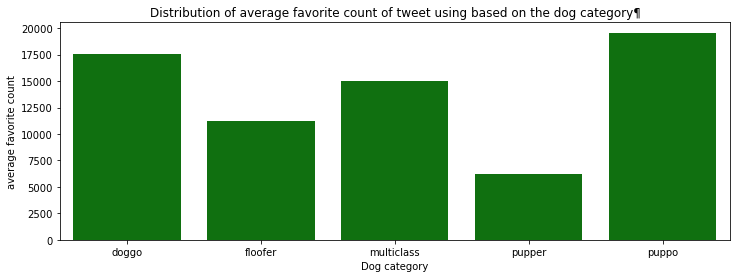

```python
distributionPlot('favorite_count','average favorite count',"Distribution of average favorite count of tweet using based on the dog category¶")
plt.savefig('av_favcounte.png')
```

### Plotting the distribution of average retweet count based on the dog category

```
  dog_category  retweet_count
0        doggo    5972.709677
1      floofer    3985.285714
2   multiclass    4548.272727
3       pupper    1909.453202
4        puppo    5325.318182
```

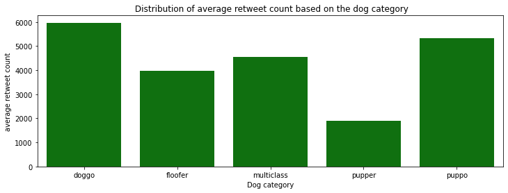

```python
distributionPlot('retweet_count','average retweet count',' Distribution of average retweet count based on the dog category')
plt.savefig('av_retweet_count.png')
```

### Plotting likes vs retweets

```python
likes = pd.Series(data=master_df['favorite_count'].values, index=master_df['timestamp'])
retweets = pd.Series(data=master_df['retweet_count'].values, index=master_df['timestamp'])
```

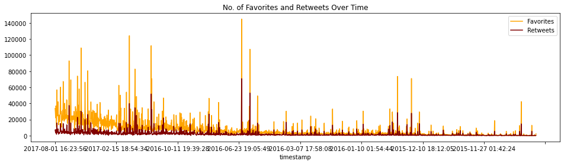

```python
likes.plot(figsize=(16,4), label='Favorites', color='orange', legend=True)
retweets.plot(figsize=(16,4), label='Retweets', color='maroon', legend=True);
plt.title('No. of Favorites and Retweets Over Time')
plt.show()
plt.savefig('retvs.png')
```

### Visualizing the most used devices by WeRateDogs users

```
Twitter for iPhone     2016
Vine - Make a Scene      91
Twitter Web Client       31
TweetDeck                10
Name: source, dtype: int64
```

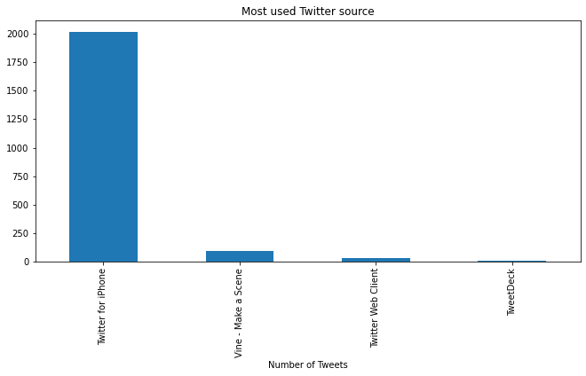

```python
print(twitter_archive_clean.source.value_counts())
twitter_archive_clean.source.value_counts().plot(kind='bar', figsize=(11,5), title='Most used Twitter source').set_xlabel("Number of Tweets")
plt.savefig('twitter_source')
plt.savefig('twitter_source.png')
```

From the bar plot above, most of the WeRateDogs users used Twitter for iPhone

### Displaying the most common name among the dogs

```python
master_df['name'].value_counts()[1:13]
```

```
Charlie    10
Oliver     10
Lucy        9
Tucker      9
Penny       9
Winston     8
Sadie       8
Toby        7
Daisy       7
Lola        7
Koda        6
Bo          6
Name: name, dtype: int64
```

### Visualizing the most popular name of the dogs

```
Index(['Charlie', 'Oliver', 'Lucy', 'Tucker', 'Penny', 'Winston', 'Sadie',
       'Toby', 'Daisy', 'Lola', 'Koda', 'Bo'],
      dtype='object')
```

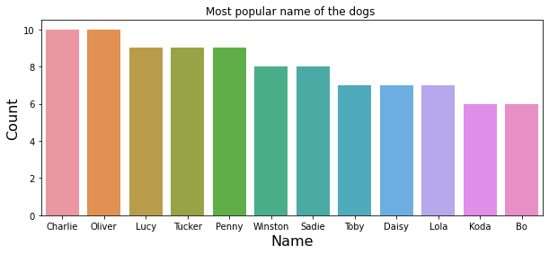

```python
sorted_order = master_df['name'].value_counts()[1:13].head(13).index
display(sorted_order)
plt.figure(figsize = (10,4))
values = np.count_nonzero(master_df['name'])
fclrs = ['grey' if (x > min(sorted_order)) else 'red' for x in sorted_order]
sns.countplot(data = master_df, x = 'name', order = sorted_order, orient = 'h')
plt.xlabel('Name', fontsize =16)
plt.ylabel('Count', fontsize =16);
plt.title('Most popular name of the dogs ')
plt.savefig('popular_dog_name.png')
```

From the above plot the most common name among the dogs are Charlie, Oliver, Lucy, Tucker, Penny, Winston, Sadie,Toby, Daisy, Lola, Koda and Bo

### Visualizing 20 dogs breed P2 predicted by twitter user on WeRateDogs

```
Labrador retriever          95
Golden retriever            79
Cardigan                    73
Chihuahua                   41
Chesapeake bay retriever    40
French bulldog              39
Pomeranian                  39
Toy poodle                  35
Siberian husky              33
Miniature poodle            32
Cocker spaniel              30
Beagle                      28
Eskimo dog                  27
Collie                      26
Pembroke                    25
Italian greyhound           22
Kuvasz                      21
Pekinese                    21
Chow                        20
Miniature pinscher          20
Name: p2, dtype: int64
```

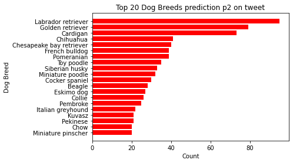

```python
breeds= master_df.p2.value_counts().head(20)
display(breeds)
plt.barh(breeds.index , breeds,color='red')
plt.xlabel('Count')
plt.ylabel('Dog Breed')
plt.title('Top 20 Dog Breeds prediction p2 on tweet')
plt.gca().invert_yaxis()
plt.show()
plt.savefig('20p2_dog_pred.png')
```

From the above plot, the most predicted dog image by twitter users on WeRateDogs is Labrador retriever

### Visualizing 20 dogs breed P3 predicted by twitter user on WeRateDogs

```
Labrador retriever                74
Chihuahua                         57
Golden retriever                  45
Eskimo dog                        35
Kelpie                            33
Kuvasz                            31
Chow                              30
Toy poodle                        29
Beagle                            29
Staffordshire bullterrier         29
Pekinese                          28
Cocker spaniel                    27
Pomeranian                        26
Pembroke                          26
Malamute                          25
French bulldog                    25
Great pyrenees                    25
Cardigan                          23
American staffordshire terrier    22
Chesapeake bay retriever          22
Name: p3, dtype: int64
```

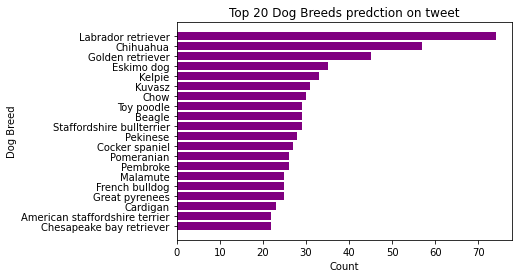

```python
breeds= master_df.p3.value_counts().head(20)
display(breeds)
plt.barh(breeds.index , breeds,color='purple')
plt.xlabel('Count')
plt.ylabel('Dog Breed')
plt.title('Top 20 Dog Breeds predction on tweet')
plt.gca().invert_yaxis()
plt.show()
plt.savefig('20d0gs_p3.png')
```

From the above plot, the most predicted dog image by twitter users on WeRateDogs is Labrador retriver

#### Visualizing the dog category with the highest score

- Creating a new column called rating in master_df

```python
master_df['rating'] = master_df['rating_numerator']/master_df['rating_denominator']
```

```
dog_category
doggo         1.4
floofer       1.3
multiclass    1.3
pupper        2.7
puppo         1.4
Name: rating, dtype: float64
```

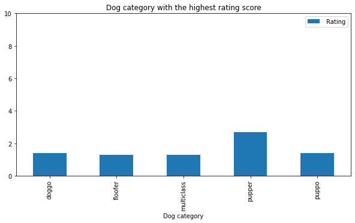

```python
dog_rating=master_df.groupby('dog_category')['rating'].max()
print(dog_rating)
dog_rating.plot.bar(figsize=(10,5))
plt.ylim(top=10)
plt.title("Dog category with the highest rating score")
plt.xlabel("Dog category")
plt.legend([" Rating"])
plt.savefig('rating.png')
```

- From the plot above, pupper is the dog with the high rating score

### Visualizing the dog category with maximun favorite count

```
dog_category
doggo         144774
floofer        28112
multiclass     49401
pupper        108900
puppo         124103
Name: favorite_count, dtype: int64
```

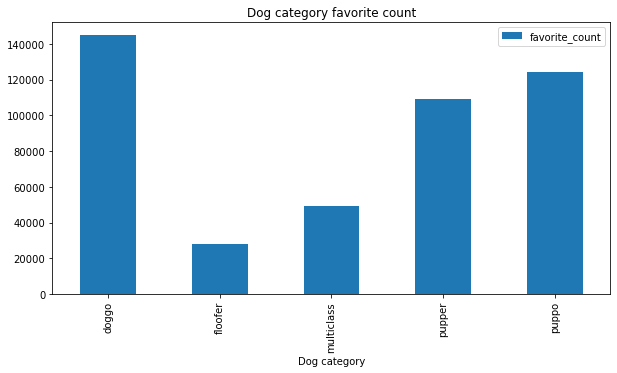

```python
dog_favorite_count=master_df.groupby('dog_category')['favorite_count'].max()
display(dog_favorite_count)
dog_favorite_count.plot.bar(figsize=(10,5))
plt.title("Dog category favorite count")
plt.xlabel("Dog category")
plt.legend(["favorite_count"])
plt.savefig('favorite.png')
```

- From the above plot doggo is the dog with maximum twitter favorite count

Visualizing the dog category with minimun retweet count

```
dog_category
doggo          568
floofer        397
multiclass    1004
pupper          80
puppo          569
Name: retweet_count, dtype: int64
```

[figure not shown]

```python
dog_retweet_count=master_df.groupby('dog_category')['retweet_count'].min()
display(dog_retweet_count)
dog_retweet_count.plot.bar(figsize=(10,5))
plt.title("Dog category with minimun retweet count")
plt.xlabel("Dog category")
plt.legend(["favorite_count"])
plt.savefig('retweet.png')
```

- From the above plot pupper has the least retweet count

#### Visualizing Total Tweets made by WeRateDogs per month between 2015 to 2017

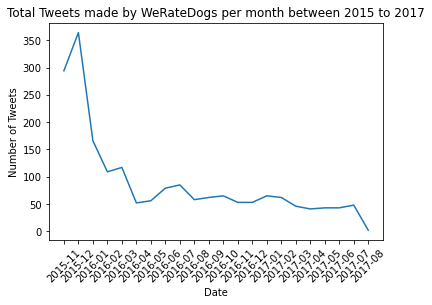

```python
twitter_archive_master['year_month_date'] = twitter_archive_master['timestamp'].dt.year.astype(str) + '-' + \
                                            twitter_archive_master['timestamp'].dt.month.astype(str).str.pad(2, fillchar='0')
twitter_archive_master['is_tweet'] = np.where(twitter_archive_master.tweet_id.notnull(), 1, 0)
twitter_archive_monthly_tweets = twitter_archive_master.groupby('year_month_date').is_tweet.sum().reset_index()
plt.xticks(rotation=45)
ax = sns.lineplot(x='year_month_date', y='is_tweet', data=twitter_archive_monthly_tweets)
ax.set_title('Total Tweets made by WeRateDogs per month between 2015 to 2017')
ax.set_xlabel('Date')
ax.set_ylabel('Number of Tweets')
```

### Visualizing some of the dogs image prediction p1

```python
twitter_archive_master[['jpg_url','p1']]
```

|  | jpg_url | p1 |
| --- | --- | --- |
| 0 | https://pbs.twimg.com/media/DGKD1-bXoAAIAUK.jpg | Orange |
| 1 | https://pbs.twimg.com/media/DGGmoV4XsAAUL6n.jpg | Chihuahua |
| 2 | https://pbs.twimg.com/media/DGBdLU1WsAANxJ9.jpg | Chihuahua |
| 3 | https://pbs.twimg.com/media/DF_q7IAWsAEuuN8.jpg | Paper towel |
| 4 | https://pbs.twimg.com/media/DF6hr6BUMAAzZgT.jpg | Basset |
| ... | ... | ... |
| 1958 | https://pbs.twimg.com/media/CT5IQmsXIAAKY4A.jpg | Miniature pinscher |
| 1959 | https://pbs.twimg.com/media/CT5Dr8HUEAA-lEu.jpg | Rhodesian ridgeback |
| 1960 | https://pbs.twimg.com/media/CT4521TWwAEvMyu.jpg | German shepherd |
| 1961 | https://pbs.twimg.com/media/CT42GRgUYAA5iDo.jpg | Redbone |
| 1962 | https://pbs.twimg.com/media/CT4udn0WwAA0aMy.jpg | Welsh springer spaniel |

1963 rows × 2 columns

#### - Miniature_pinscher

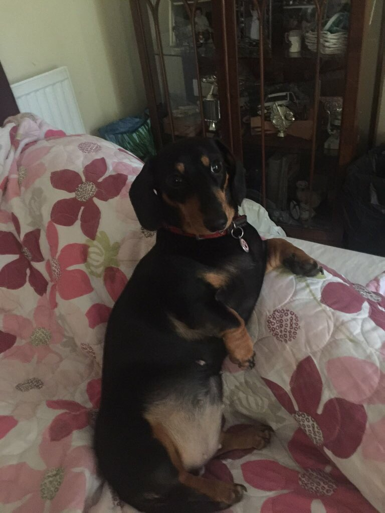

```python
Image("https://pbs.twimg.com/media/CT5IQmsXIAAKY4A.jpg")
```

### Programmatically download the image from the url

```python
response = requests.get("https://pbs.twimg.com/media/CT5IQmsXIAAKY4A.jpg")
file = open("Miniature_pinscher.png", "wb")
file.write(response.content)
file.close()
```

#### - German Sheperd

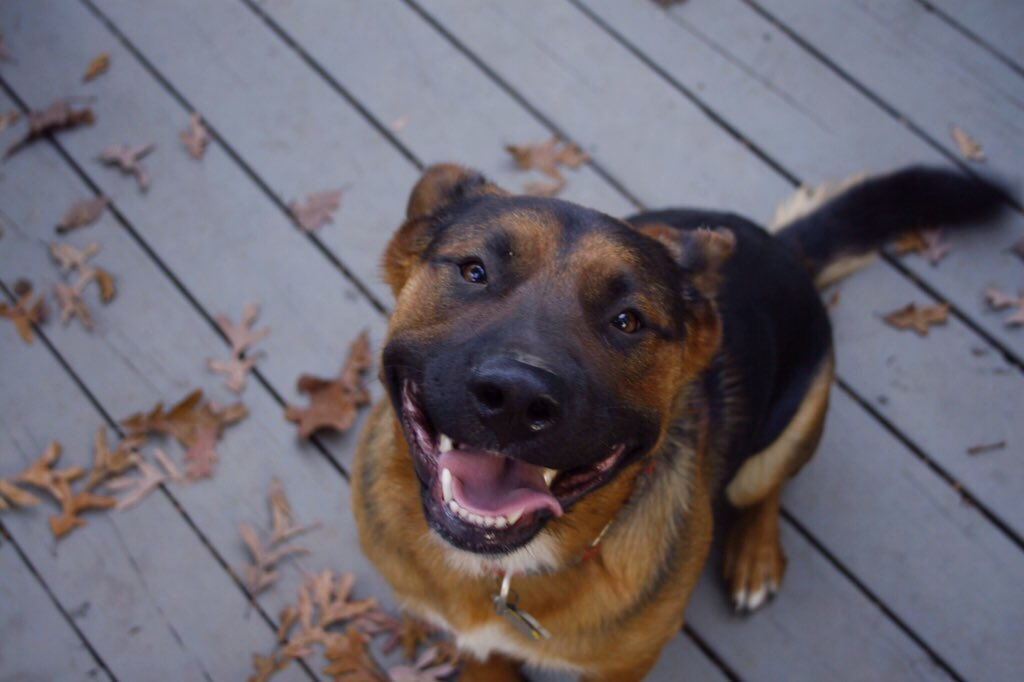

```python
Image('https://pbs.twimg.com/media/CT4521TWwAEvMyu.jpg')
```

#### Programmatically download the image

```python
response = requests.get("https://pbs.twimg.com/media/CT4521TWwAEvMyu.jpg")
file = open("german_sheperd.png", "wb")
file.write(response.content)
file.close()
```

#### - Rhodesian ridgeback

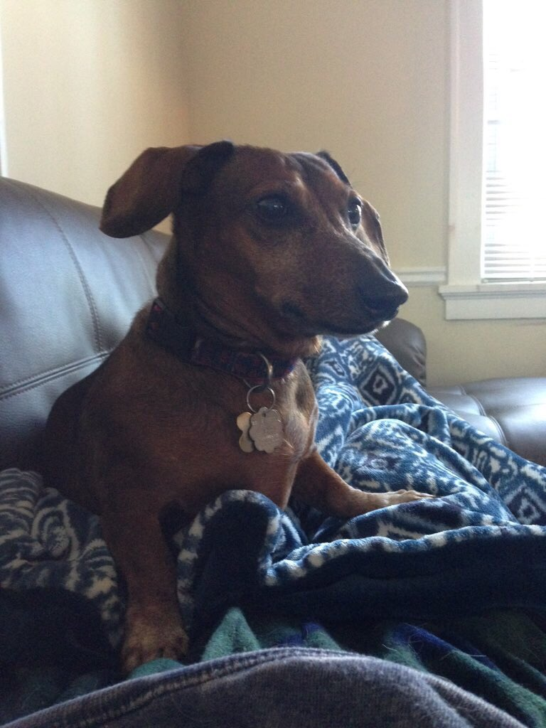

```python
Image('https://pbs.twimg.com/media/CT5Dr8HUEAA-lEu.jpg')
```

#### Programmatically download the image

```python
response = requests.get("https://pbs.twimg.com/media/CT5Dr8HUEAA-lEu.jpg")
file = open("Rhodesian ridgeback.png", "wb")
file.write(response.content)
file.close()
```

#### Reference

https://www.adamsmith.haus/python/answers/how-to-download-an-image-using-requests-in-python https://pandas.pydata.org/pandas-docs/stable/reference/api/pandas.isnull.html  
https://docs.python.org/3/library/re.html  
https://pythonexamples.org/pandas-dataframes-inner-join/  
https://www.geeksforgeeks.org/read-json-file-using-python/  
https://www.youtube.com/watch?v=mE_tz0U5PL4  
https://developer.twitter.com/en/portal/petition/essential/basic-info